# project 1

Karol Mućk

25 03 2022

# Task 1

```r
library(fpp2)
library(ggplot2)
library(forecast)
```

Fristly, let’s read data.

```r
www = "https://www.mimuw.edu.pl/~noble/courses/TimeSeries/data/w-gs1yr.txt"
gs1yr <- read.csv(www, sep="")


www2 = "https://www.mimuw.edu.pl/~noble/courses/TimeSeries/data/w-gs3yr.txt"
gs3yr <- read.csv(www2, sep="")
```

Create variables

```r
r1 <- gs1yr$rate
r3 <- gs3yr$rate
```

and plot r1 and r3

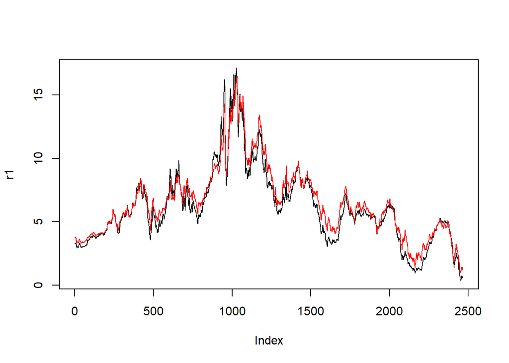

```r
plot(r1, type='l')
lines(r3,col="red")
```

Now, we make linear regression and plot results.

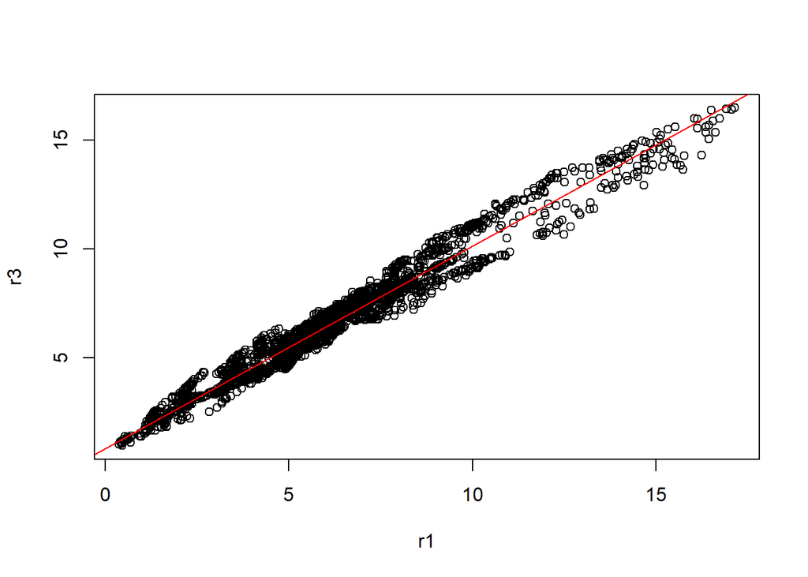

```r
m1 <- lm(r3~r1)

plot(r1,r3)
abline(m1, col= 'red')
```

Looking on the plot, we can see that our regression fit to the data quite well. We also can see that r1 and r3 high linear correlation. Let’s analyze this more deeply.

```r
summary(m1)
```

```
##
## Call:
## lm(formula = r3 ~ r1)
##
## Residuals:
##      Min       1Q   Median       3Q      Max
## -1.82319 -0.37691 -0.01462  0.38661  1.35679
##
## Coefficients:
##             Estimate Std. Error t value Pr(>|t|)
## (Intercept)  0.83214    0.02417   34.43   <2e-16 ***
## r1           0.92955    0.00357  260.40   <2e-16 ***
## ---
## Signif. codes:  0 '***' 0.001 '**' 0.01 '*' 0.05 '.' 0.1 ' ' 1
##
## Residual standard error: 0.5228 on 2465 degrees of freedom
## Multiple R-squared:  0.9649, Adjusted R-squared:  0.9649
## F-statistic: 6.781e+04 on 1 and 2465 DF,  p-value: < 2.2e-16
```

Looking at resiudals, ideally the quantiles and min/max should be symmetrically away from 0, with the median possibly close to zero. We have this scenario, which is a good indication of our model.

We can see that both slope and intercept have a significant statistical effect on the result because the p-value is very low for them (<<0.05). This confirming that the regression fit very well

Also, $R^2$ is very close to 1, Which agrees with what we see in the graph (all data are very close to the regression).

In summary, our regression fits the data very good.

Let’s analyze residuals.

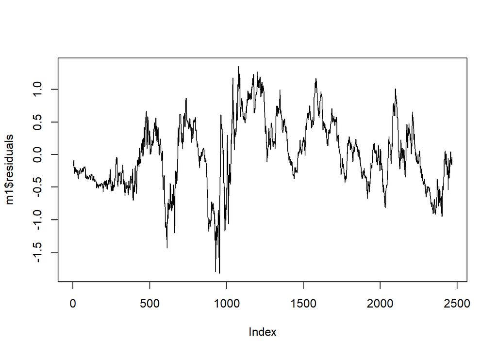

```r
plot(m1$residuals, type = 'l')
```

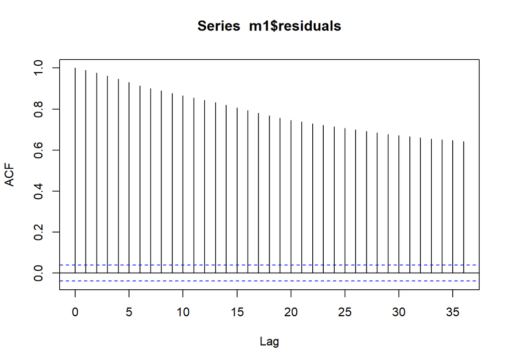

```r
acf(m1$residuals, lag=36)
```

As we can see, the residuals are not white noise (for example, in the acf plot).

Now, let’s make linear regression on diff values.

```r
c1 = diff(r1)
c3 = diff(r3)
m2 = lm(c3~-1+c1)
```

And plot the results.

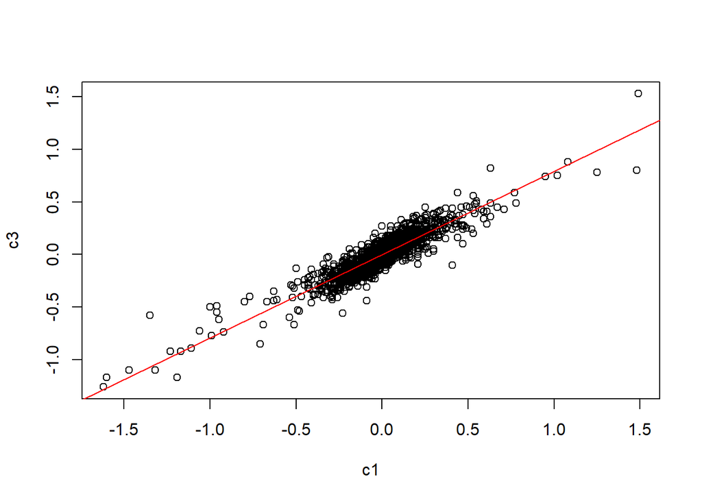

```r
plot(c1,c3)
abline(m2, col= 'red')
```

```r
summary(m2)
```

```
##
## Call:
## lm(formula = c3 ~ -1 + c1)
##
## Residuals:
##      Min       1Q   Median       3Q      Max
## -0.42469 -0.03589 -0.00127  0.03456  0.48911
##
## Coefficients:
##    Estimate Std. Error t value Pr(>|t|)
## c1 0.791935   0.007337   107.9   <2e-16 ***
## ---
## Signif. codes:  0 '***' 0.001 '**' 0.01 '*' 0.05 '.' 0.1 ' ' 1
##
## Residual standard error: 0.06896 on 2465 degrees of freedom
## Multiple R-squared:  0.8253, Adjusted R-squared:  0.8253
## F-statistic: 1.165e+04 on 1 and 2465 DF,  p-value: < 2.2e-16
```

Again, we can see that differences have linear correlations, so we can expect that our time series should drop and grow on very similar levels.

Let’s analyze residuals and fit MA(1) model to residuals

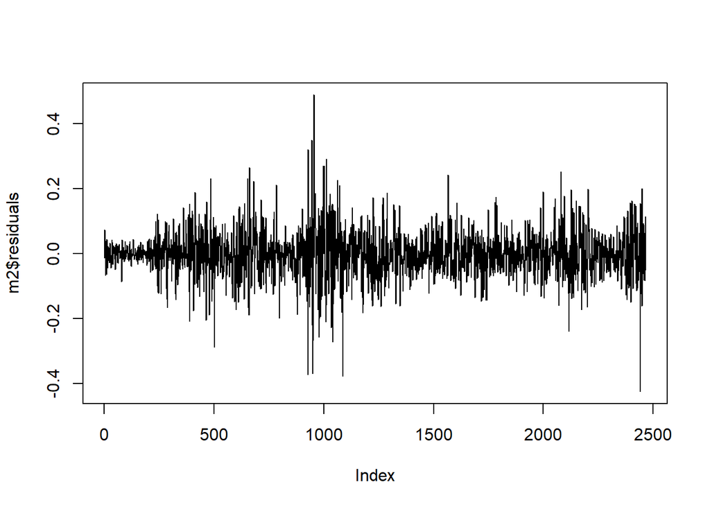

```r
plot(m2$residuals, type ='l')
```

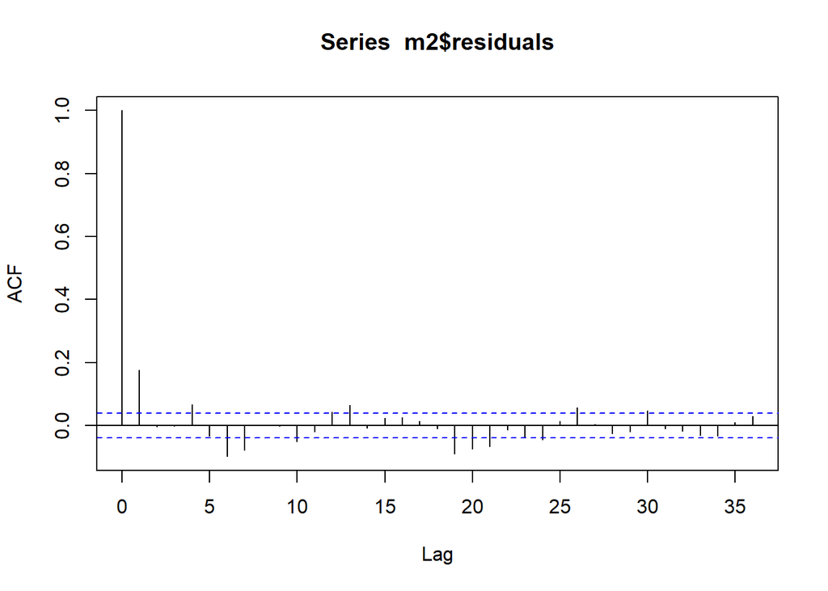

```r
acf(m2$residuals, lag = 36)
```

```r
m3 = arima(c3, order = c(0,0,1), xreg=c1, include.mean = F)
m3
```

```
##
## Call:
## arima(x = c3, order = c(0, 0, 1), xreg = c1, include.mean = F)
##
## Coefficients:
##          ma1      c1
##       0.1823  0.7936
## s.e.  0.0196  0.0075
##
## sigma^2 estimated as 0.0046:  log likelihood = 3136.62,  aic = -6267.23
```

and plot results.

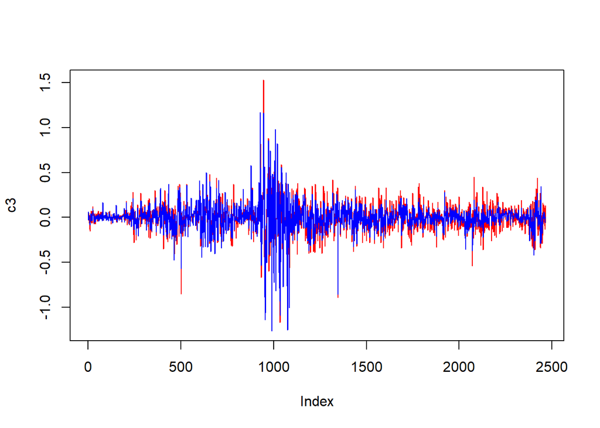

```r
plot(c3,col="red", type='l')
lines(c3- m3$residuals,col="blue")
```

We can see that regression part of model is equal to $0.7935840$ and aic is super low $(-6267.23)$, and our model fit very vell to data. Model is based on c1 time-seires, so again we can confirm that only looking on c1 time-seires we should be able to predict behaviour of c3 time-series.

```r
m3$coef
```

```
##       ma1        c1
## 0.1823359 0.7935840
```

Finaly, we calculae $R^{2}$

```r
rsq = (sum(c3^2)-sum(m3$residuals^2))/sum(c3^2)
rsq
```

```
## [1] 0.8310077
```

$R^{2}$ is quite high, so this indicates the c3 stock performance moves relatively in line with the c1 index, and our model quite good explain varaiance of c3 time-series.

Strategy

We see a high correlation between one time series (I think that one time series responds to the other). A very good strategy is (if we had information about one of the series) to do exactly like that time series i.e. if we know that tomorrow one of the series will rise, our series will also rise and vice versa. So if we know that one of the series will rise tomorrow, we should wait, if we know that it will fall, we should sell.

# Task 2

Let’s read data and make time series x_t and y_t

```r
www = "https://www.mimuw.edu.pl/~noble/courses/TimeSeries/data/sp5may.dat"
data <- read.csv(www, sep="")

y = diff(data$lnfuture)
x = diff(data$lnspot)
```

We want to find a model $y_{t} = \beta_{0} +\beta_{1}x_{t} + \epsilon_{t}$

Now, we can plot data.

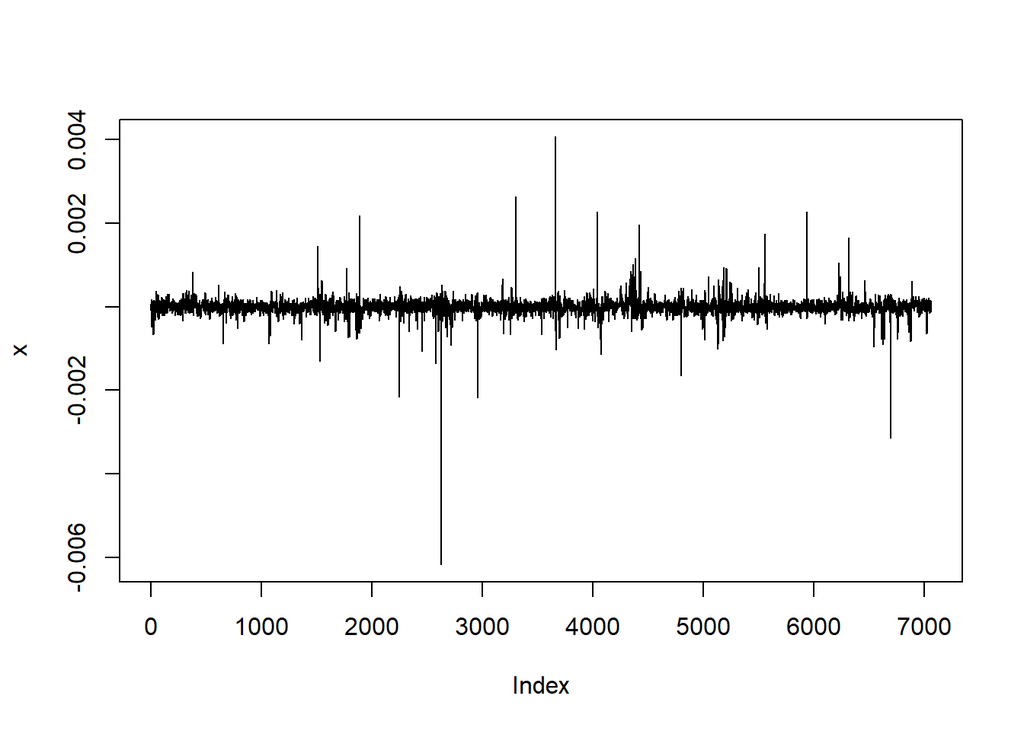

```r
plot(x, type ='l')
```

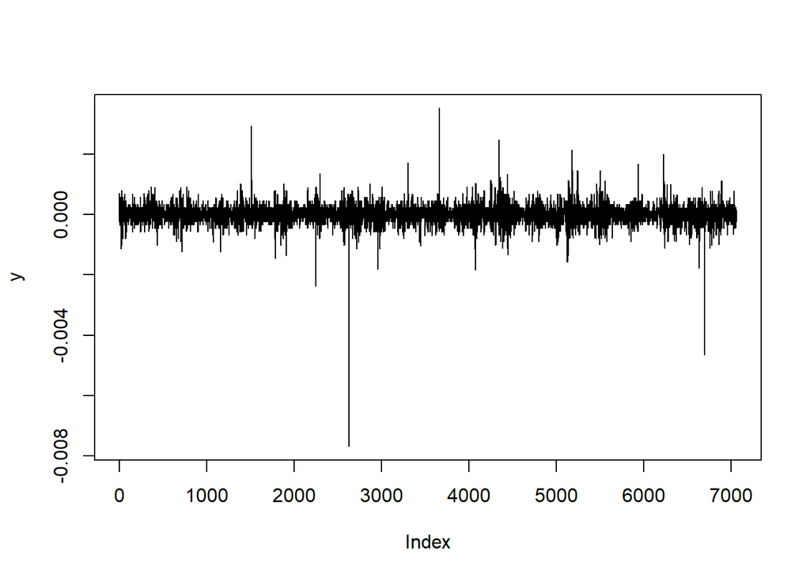

```r
plot(y, type ='l')
```

let’s make simple linear regression

```r
regmodel=lm(y~x)
summary(regmodel)
```

```
##
## Call:
## lm(formula = y ~ x)
##
## Residuals:
##        Min         1Q     Median         3Q        Max
## -0.0038484 -0.0001568 -0.0000014  0.0001612  0.0026256
##
## Coefficients:
##              Estimate Std. Error t value Pr(>|t|)
## (Intercept) 1.354e-06  3.509e-06   0.386      0.7
## x           6.212e-01  1.754e-02  35.420   <2e-16 ***
## ---
## Signif. codes:  0 '***' 0.001 '**' 0.01 '*' 0.05 '.' 0.1 ' ' 1
##
## Residual standard error: 0.0002948 on 7058 degrees of freedom
## Multiple R-squared:  0.1509, Adjusted R-squared:  0.1508
## F-statistic:  1255 on 1 and 7058 DF,  p-value: < 2.2e-16
```

and plot of the relationship between x_t and y_t

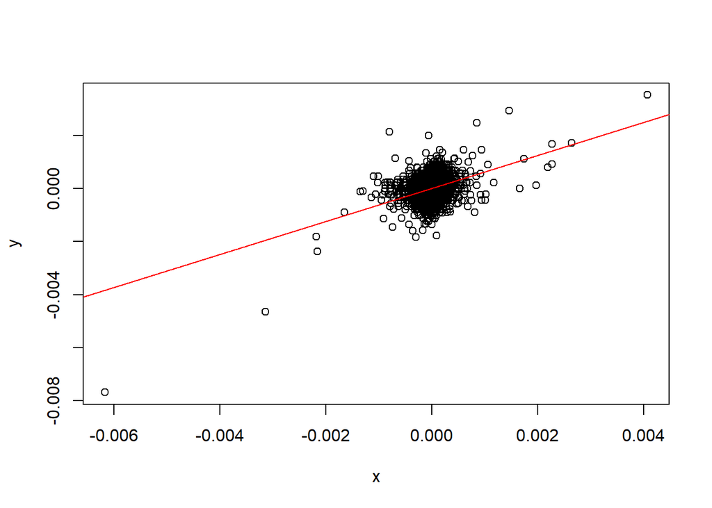

```r
plot(x,y)
abline(regmodel, col= 'red')
```

Now, we want to analyze resiudals, and find the best model to fit.

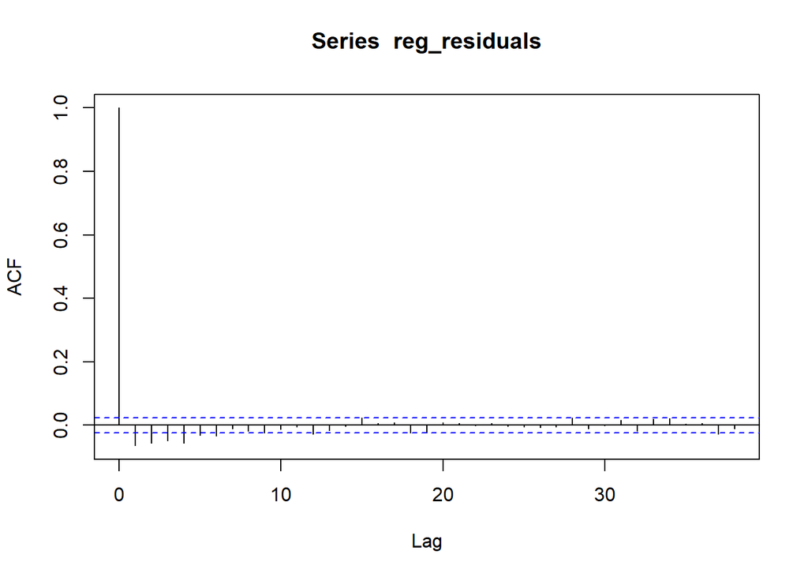

```r
reg_residuals = residuals(regmodel)

acf(reg_residuals)
```

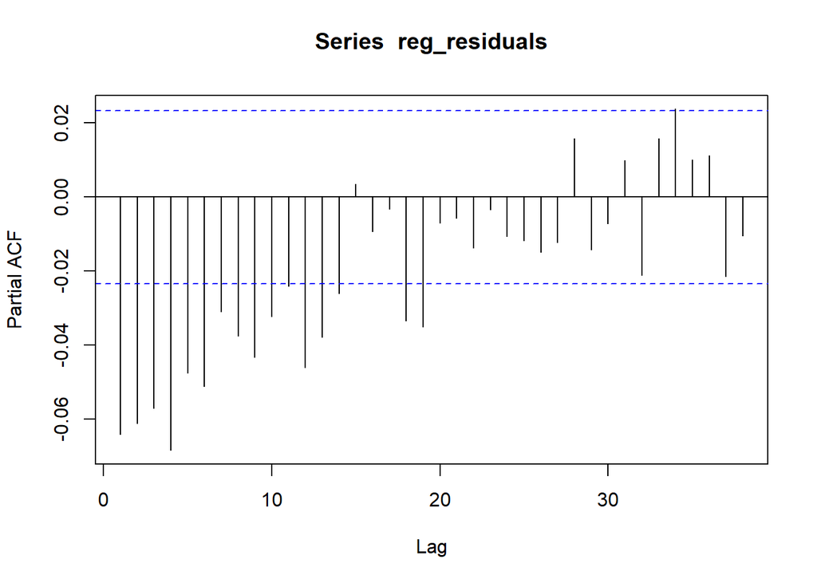

```r
pacf(reg_residuals)
```

We can fit AR(p) model to resiudals, looking at the acf plot, we should choose p = 1

```r
ar1res = arima(reg_residuals,order = c(1,0,0))

ar1res
```

```
##
## Call:
## arima(x = reg_residuals, order = c(1, 0, 0))
##
## Coefficients:
##           ar1  intercept
##       -0.0641          0
## s.e.   0.0119          0
##
## sigma^2 estimated as 8.654e-08:  log likelihood = 47389.31,  aic = -94772.63
```

In the **ar_value** variable we keep the corresponding coefficient for AR(1)

```r
ar_value <- ar1res$coef[1]
```

and we can plot our fit

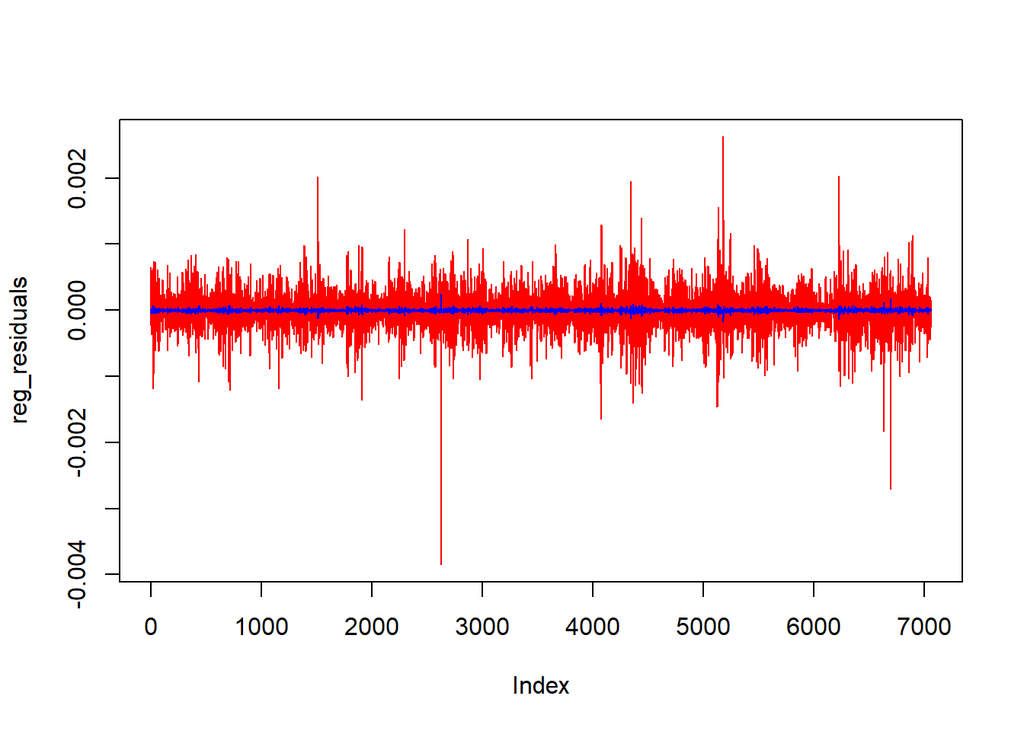

```r
plot(reg_residuals,col="red", type='l')
lines(reg_residuals - ar1res$residuals,col="blue")
```

Create new x_t, y_t (based on our fit)

```r
xl = ts.intersect(x, lag(x,-1))
xnew = xl[,1] - ar_value * xl[,2]

yl = ts.intersect(y, lag(y,-1))
ynew = yl[,1] - ar_value * yl[,2]
```

Now, we can fit regression to new x_t and y_t, so we can get $y_{t} = \beta_{0} +\beta_{1}x_{t} + \epsilon_{t}$

```r
new_reg = lm(ynew~xnew)

summary(new_reg)
```

```
##
## Call:
## lm(formula = ynew ~ xnew)
##
## Residuals:
##        Min         1Q     Median         3Q        Max
## -0.0040951 -0.0001669 -0.0000014  0.0001716  0.0027939
##
## Coefficients:
##              Estimate Std. Error t value Pr(>|t|)
## (Intercept) 1.441e-06  3.734e-06   0.386      0.7
## xnew        6.212e-01  1.754e-02  35.420   <2e-16 ***
## ---
## Signif. codes:  0 '***' 0.001 '**' 0.01 '*' 0.05 '.' 0.1 ' ' 1
##
## Residual standard error: 0.0003137 on 7058 degrees of freedom
## Multiple R-squared:  0.1509, Adjusted R-squared:  0.1508
## F-statistic:  1255 on 1 and 7058 DF,  p-value: < 2.2e-16
```

We can see how so $\beta_{0}$ and $\beta_{1}$ looks like

```r
new_reg$coefficients
```

```
##  (Intercept)         xnew
## 1.440592e-06 6.212183e-01
```

and plot results

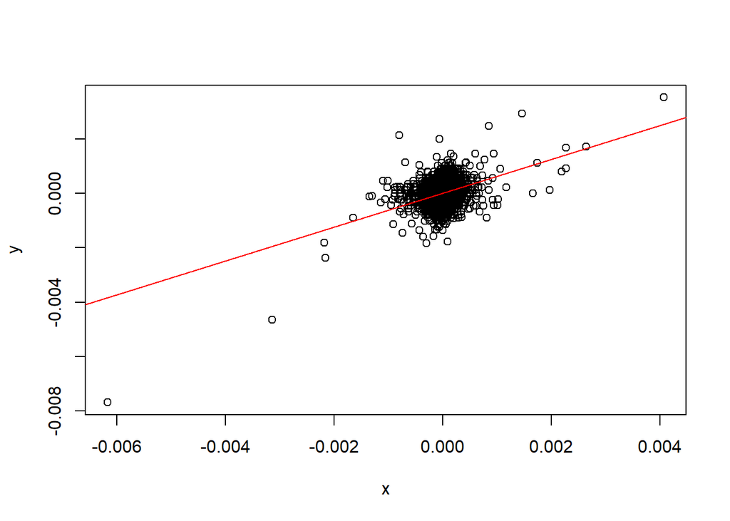

```r
plot(x, y)
abline(new_reg,col="red")
```

Resiudals

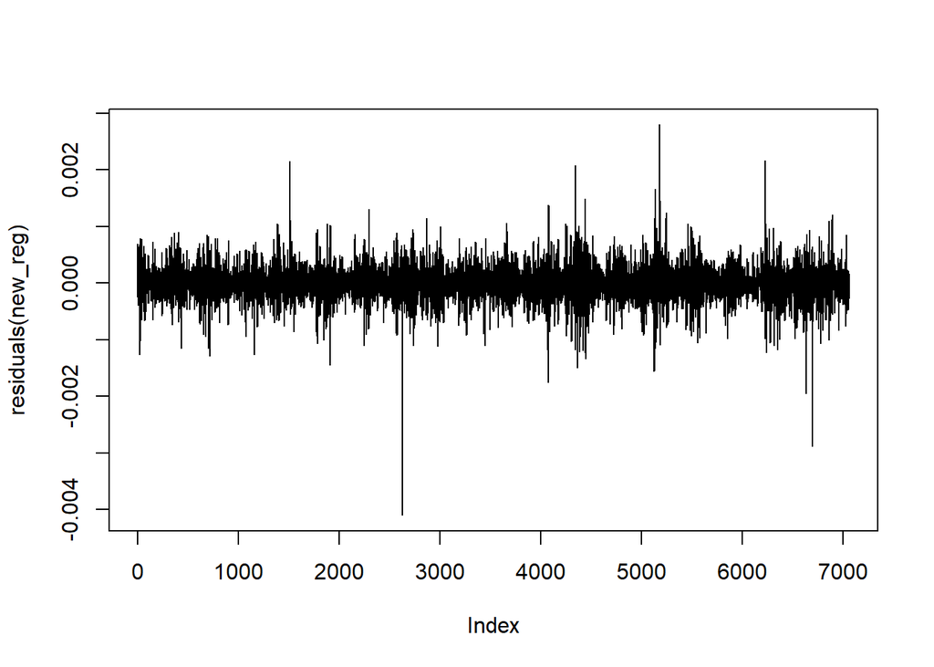

```r
plot(residuals(new_reg), type='l')
```

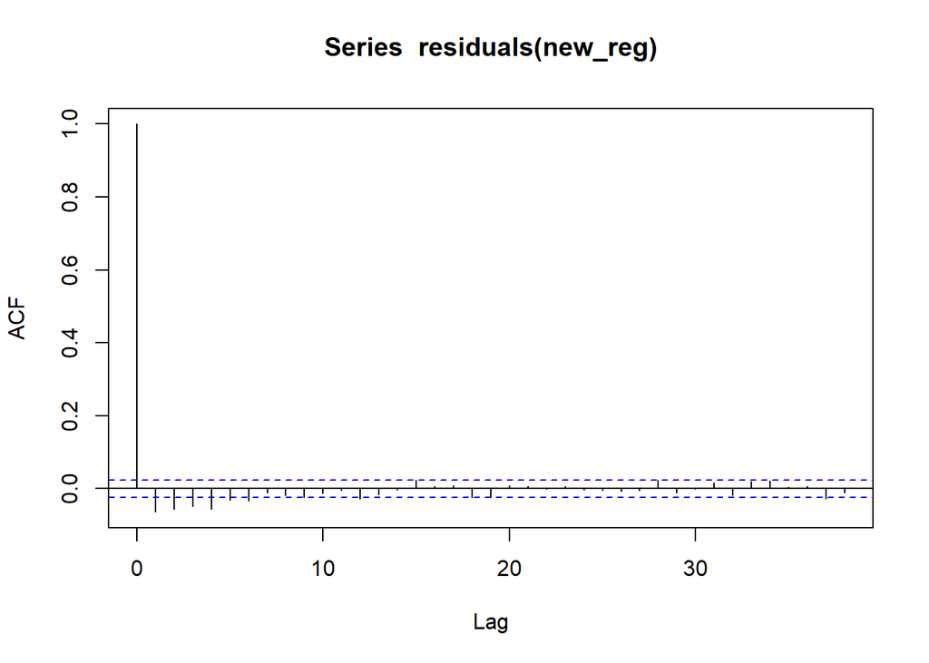

```r
acf(residuals(new_reg))
```

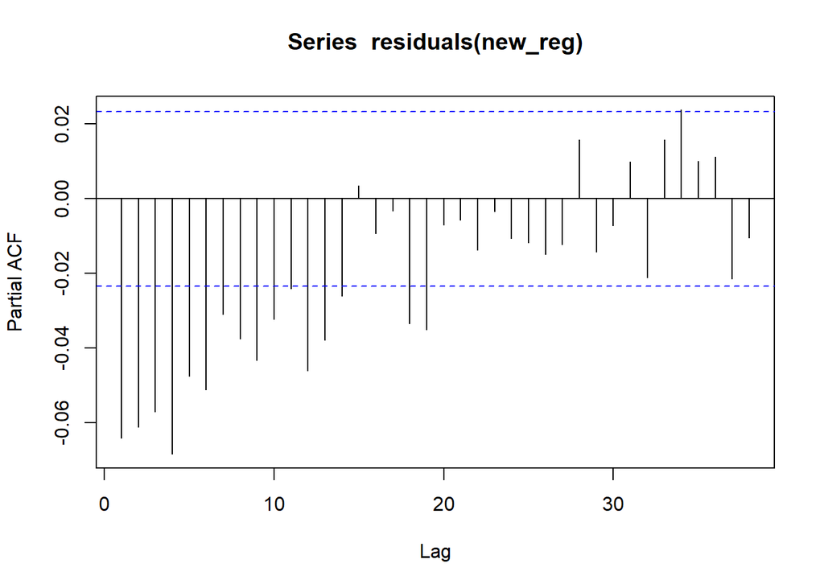

```r
pacf(residuals(new_reg))
```

I think white noise isn’t good model for resiudals, but we can try fit it and see resuts.

```r
wh_fit = arima(residuals(new_reg),order = c(0,0,0))
wh_fit
```

```
##
## Call:
## arima(x = residuals(new_reg), order = c(0, 0, 0))
##
## Coefficients:
##       intercept
##               0
## s.e.          0
##
## sigma^2 estimated as 9.84e-08:  log likelihood = 46936.25,  aic = -93868.5
```

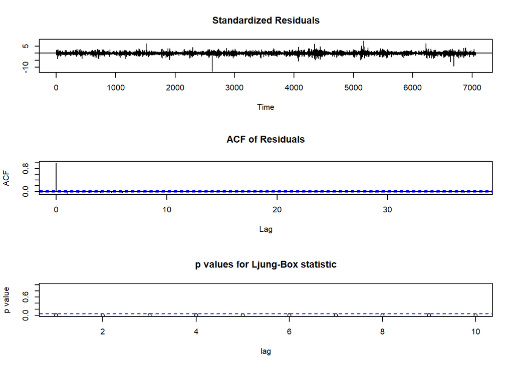

```r
tsdiag(wh_fit)
```

Let’s fit ARMA(p,q) to residuals. Looking on the acf and pacf plot is not obvius what p and q we should choose. We will use auto arima to find best model.

```r
auto_fit = auto.arima(residuals(new_reg),  max.d = 0)
auto_fit
```

```
## Series: residuals(new_reg)
## ARIMA(1,0,1) with zero mean
##
## Coefficients:
##          ar1      ma1
##       0.8179  -0.9196
## s.e.  0.0152   0.0102
##
## sigma^2 = 9.544e-08:  log likelihood = 47044.72
## AIC=-94083.44   AICc=-94083.43   BIC=-94062.85
```

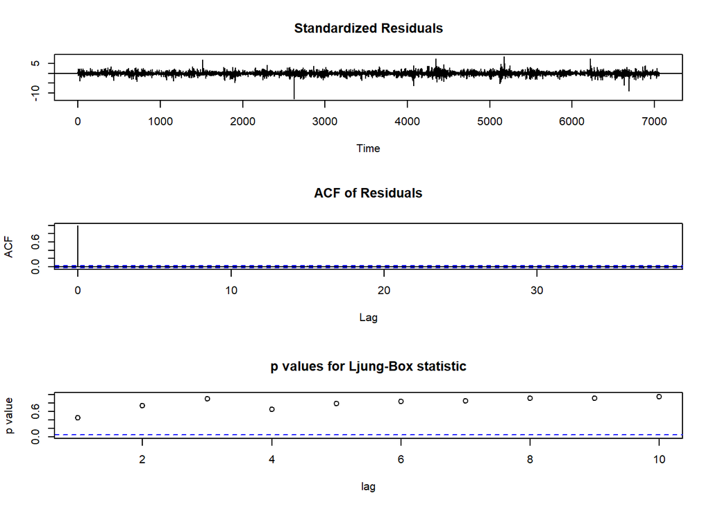

```r
tsdiag(auto_fit)
```

as I thought ARMA(1,1) was choosen as model for resiudals. This model works better that white noise.

Now, we are going to fit AR(p) model to residuals. Looking on pacf plot, we should choose p = 13, what is strange. So we are going to use auto. arima, but allow only to choose p.

```r
auto_fit2 = auto.arima(residuals(new_reg),  max.d = 0, max.q=0)
auto_fit2
```

```
## Series: residuals(new_reg)
## ARIMA(5,0,0) with zero mean
##
## Coefficients:
##           ar1      ar2      ar3      ar4      ar5
##       -0.0787  -0.0724  -0.0652  -0.0720  -0.0475
## s.e.   0.0119   0.0119   0.0119   0.0119   0.0119
##
## sigma^2 = 9.67e-08:  log likelihood = 47000
## AIC=-93987.99   AICc=-93987.98   BIC=-93946.82
```

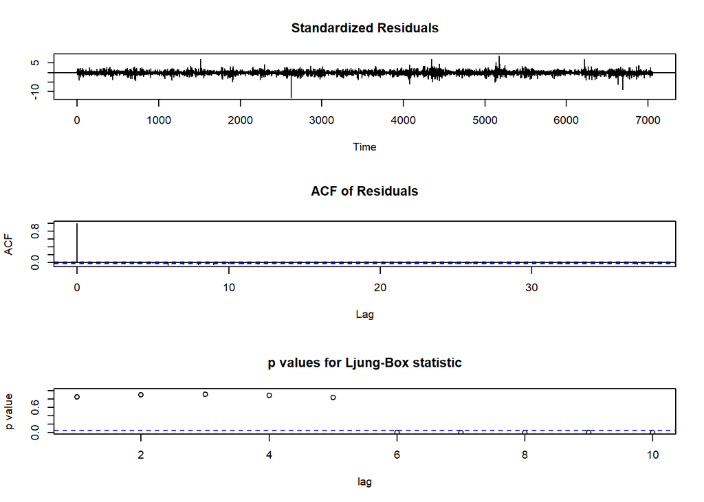

```r
tsdiag(auto_fit2)
```

GLS

We are going to use gls function to check results. This functions is very slow (need around 10h to compile) so I added screenshoot with results.

```r
# df <- data.frame(x, y)
# test = gls(y ~ x, data = df, method='ML', correlation=corARMA(p=0,q=1))
```

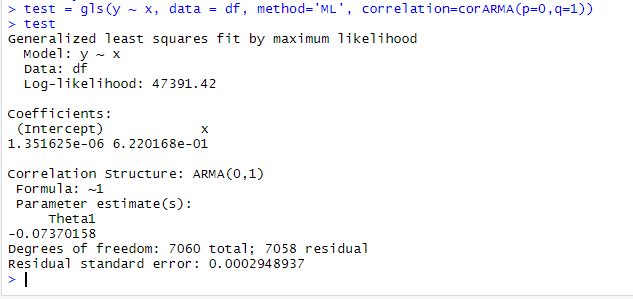

Results of gls function

We can see that slope and intercept are very close to my regression (but not the same).

# Taks 3

Fristly, read data, create ts object and plot data.

```r
www = "https://www.mimuw.edu.pl/~noble/courses/TimeSeries/data/q-gdpdef.txt"
data <- read.csv(www, sep="")


my_ts <- ts(data$gdpdef, frequency = 4)


#my_ts <- log(my_ts)
```

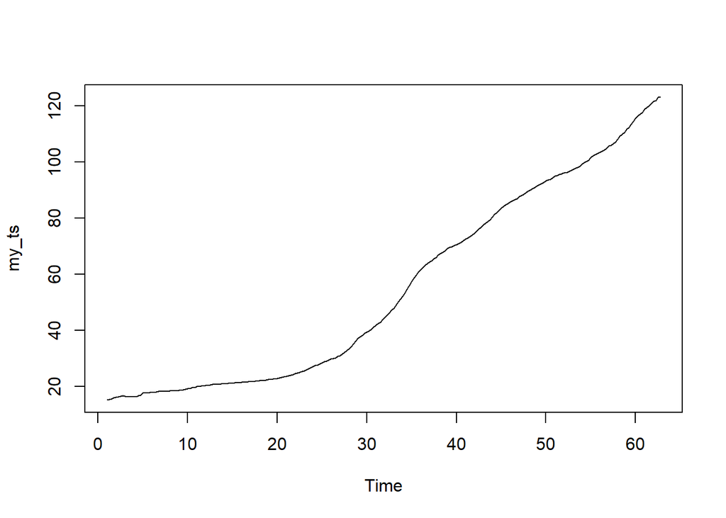

```r
plot(my_ts)
```

We can see that data is not stationary, so we have to use diff function.

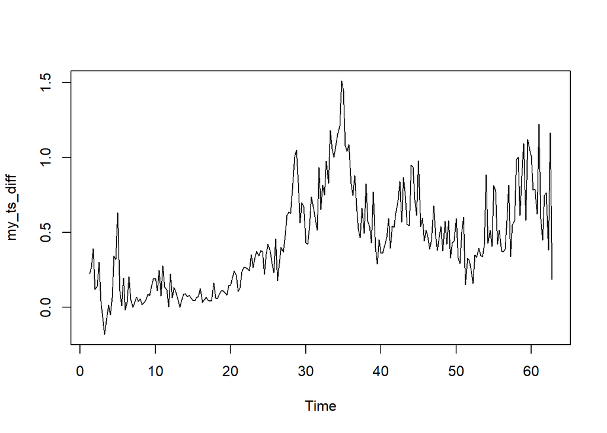

```r
my_ts_diff = diff(my_ts)

plot(my_ts_diff)
```

Still not good, we can try set differences to 2 and see results.

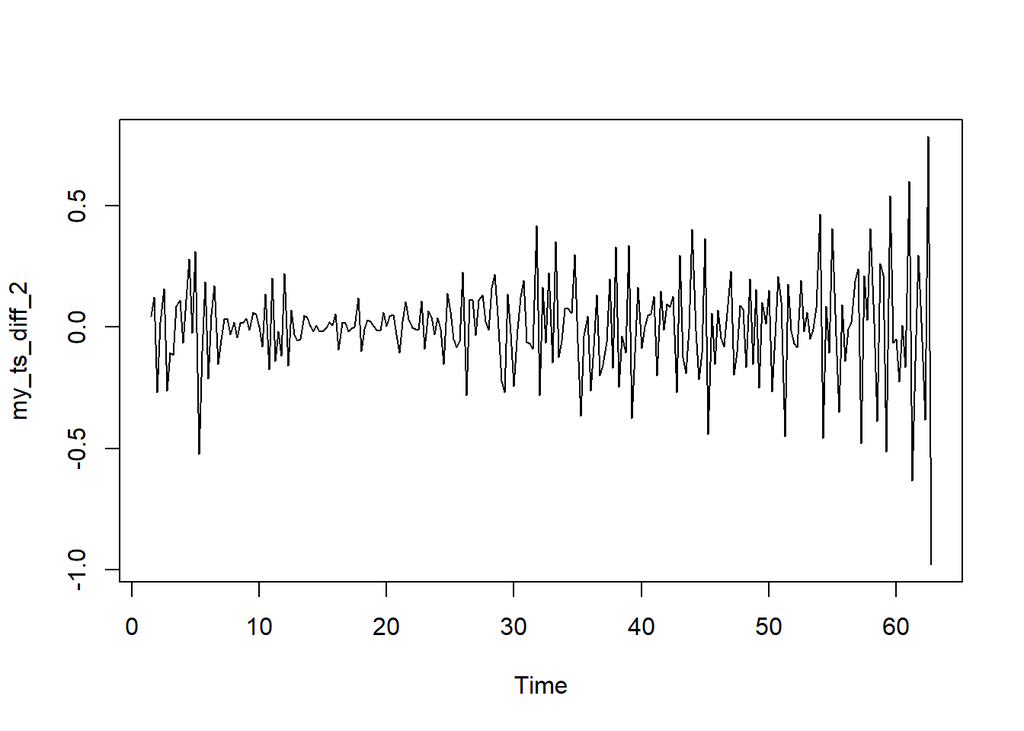

```r
my_ts_diff_2 = diff(my_ts, differences = 2)

plot(my_ts_diff_2)
```

Now, data looks ok, but variance increases. I tested use log() function, but this didn’t change the prediction much, so decided to don’t use log() and assume that this variance is not a big problem.

We can analyze it and find best model to fit.

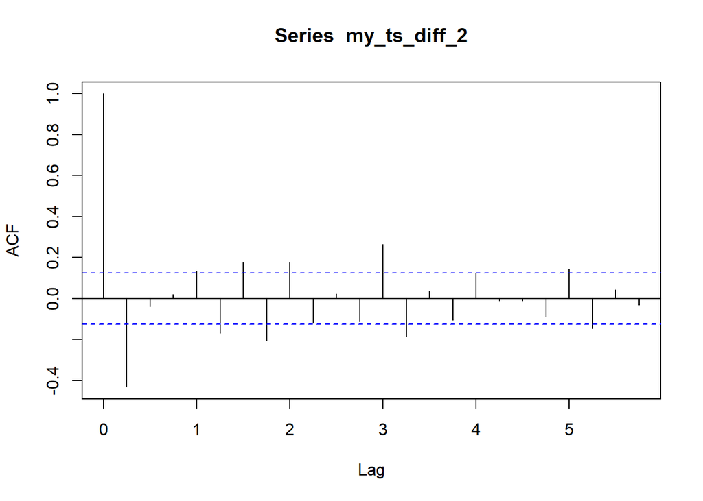

```r
acf(my_ts_diff_2)
```

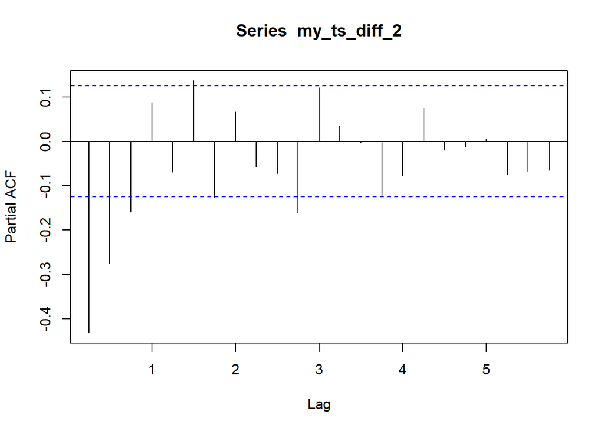

```r
pacf(my_ts_diff_2)
```

Let’s fit both models to our time-series.

MA(2)

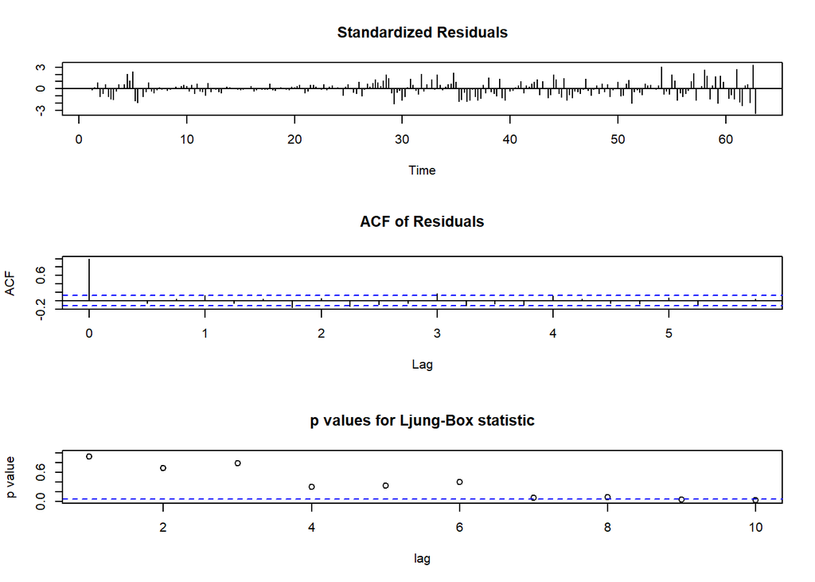

```r
fit1 = arima(my_ts,order = c(0,2,2))
tsdiag(fit1)
```

```r
fit1
```

```
##
## Call:
## arima(x = my_ts, order = c(0, 2, 2))
##
## Coefficients:
##           ma1     ma2
##       -0.6501  0.1004
## s.e.   0.0706  0.0759
##
## sigma^2 estimated as 0.02841:  log likelihood = 88.73,  aic = -171.45
```

AR(2)

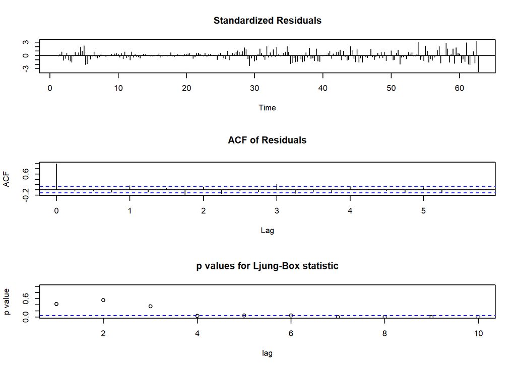

```r
fit2 = arima(my_ts,order = c(2,2,0))
tsdiag(fit2)
```

```r
fit2
```

```
##
## Call:
## arima(x = my_ts, order = c(2, 2, 0))
##
## Coefficients:
##           ar1      ar2
##       -0.5937  -0.2947
## s.e.   0.0628   0.0649
##
## sigma^2 estimated as 0.02877:  log likelihood = 87.21,  aic = -168.41
```

MA(2) + AR(2)

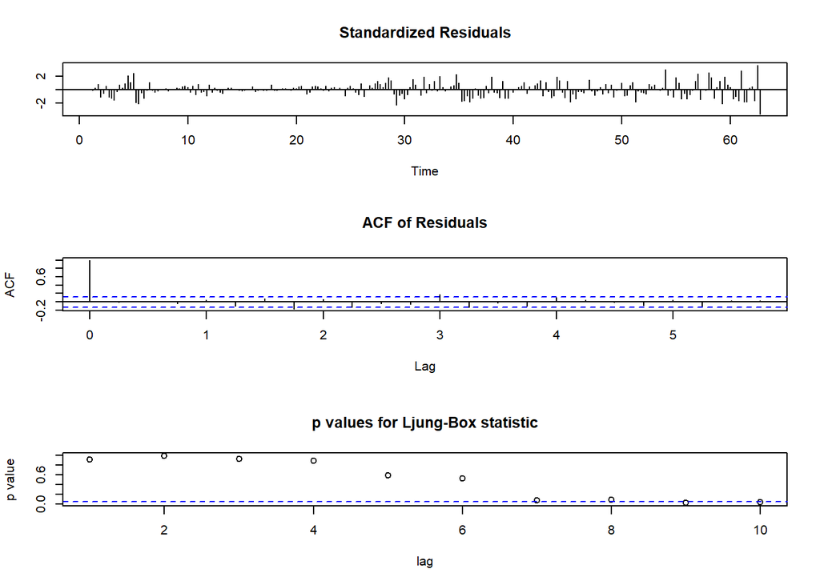

```r
fit3 = arima(my_ts,order = c(2,2,2))
tsdiag(fit3)
```

```r
fit3
```

```
##
## Call:
## arima(x = my_ts, order = c(2, 2, 2))
##
## Coefficients:
##          ar1      ar2      ma1     ma2
##       0.2519  -0.1988  -0.8867  0.3874
## s.e.  0.2924   0.1178   0.2849  0.1853
##
## sigma^2 estimated as 0.02799:  log likelihood = 90.51,  aic = -171.01
```

auto.arima

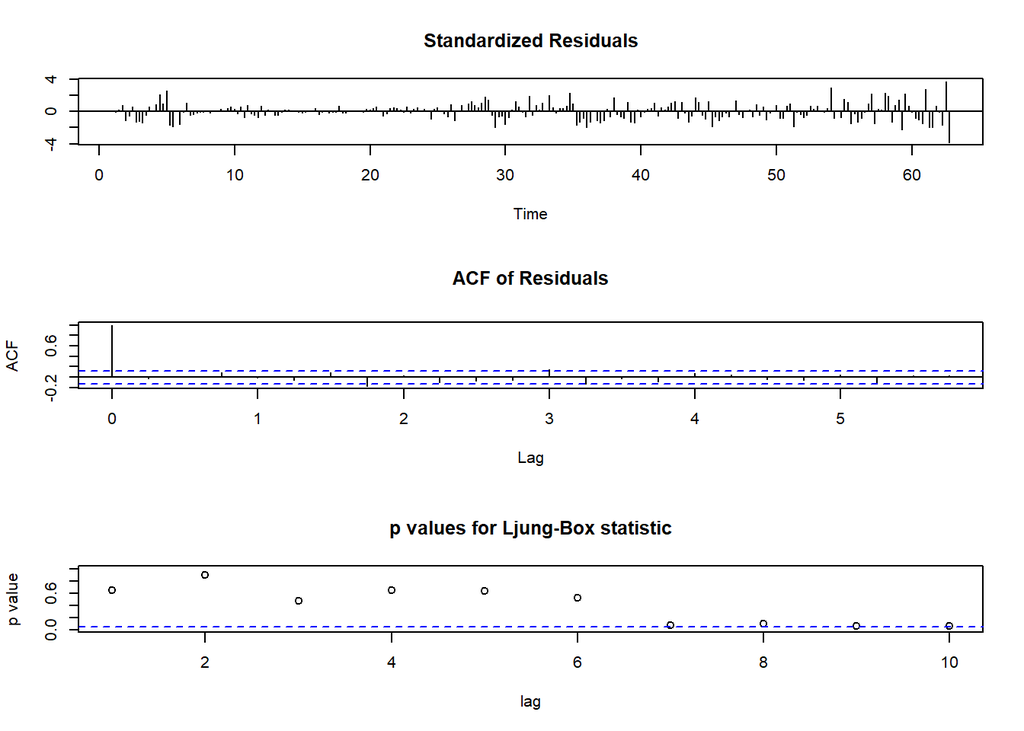

```r
fit4 = auto.arima(my_ts)
tsdiag(fit4)
```

```r
fit4
```

```
## Series: my_ts
## ARIMA(0,2,1)(2,0,1)[4]
##
## Coefficients:
##           ma1     sar1    sar2    sma1
##       -0.6041  -0.4409  0.0764  0.6017
## s.e.   0.0523   0.5131  0.1151  0.5053
##
## sigma^2 = 0.02844:  log likelihood = 90.57
## AIC=-171.15   AICc=-170.9   BIC=-153.62
```

Looking at the graphs and analyzing the residuals, it seems that the MA(2) model works best. Let’s draw it on a graph and plot the prediction.

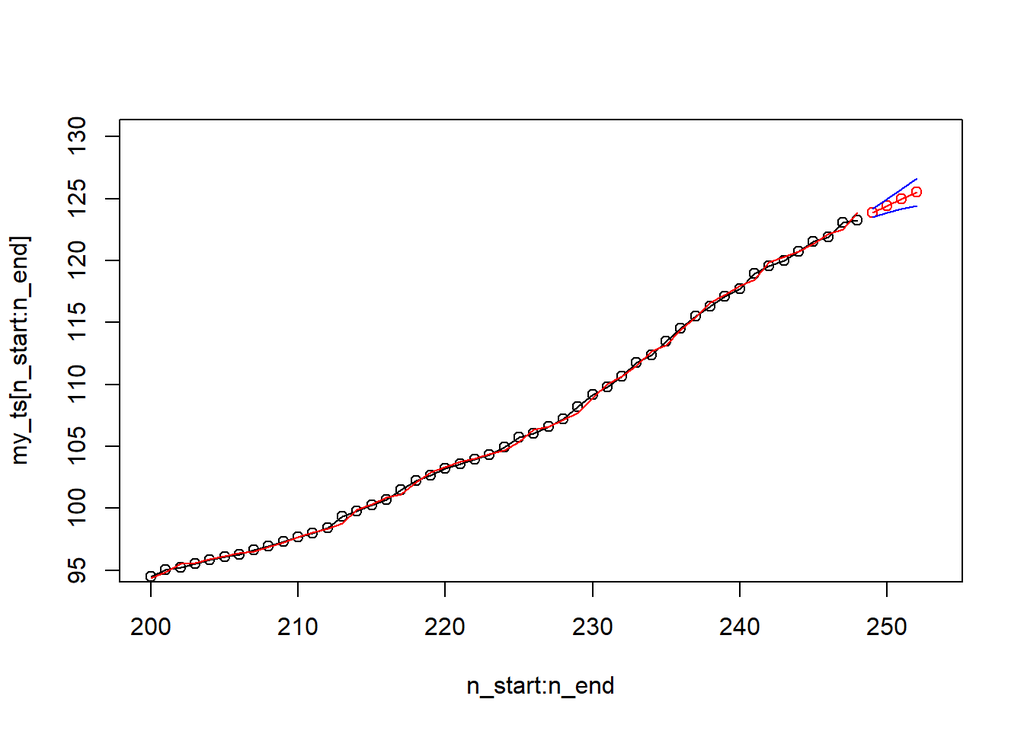

```r
n_start = 200
n_end = length(my_ts)
n_pred = 4
y_dim = 130

# fitted values

plot(n_start:n_end, my_ts[n_start:n_end], xlim = c(n_start, n_end+n_pred+1), ylim=c(min(my_ts[n_start:n_end])+1, y_dim))
lines(n_start:n_end,my_ts[n_start:n_end], type="l" )
lines(n_start:n_end, my_ts[n_start:n_end]-fit2$residuals[n_start:n_end], type="l", col="red")

# forecast for 10 steps ahead
forecast = predict(fit1, n.ahead=4)
lines((n_end+1):(n_end+n_pred), forecast$pred, type="o", col="red")
lines((n_end+1):(n_end+n_pred), forecast$pred-1.96*forecast$se, col="blue")
lines((n_end+1):(n_end+n_pred), forecast$pred+1.96*forecast$se, col="blue")
```

Our predictions for 2009:

```r
forecast$pred
```

```
##        Qtr1     Qtr2     Qtr3     Qtr4
## 63 123.8650 124.4278 124.9906 125.5534
```

Thanks for reading, that’s all.